# STAT2050 Final Project

Cody Strange

2023-11-29

```r
head(data)
```

```
##   ID Age Smoke Quetelet Vitamin Calories  Fat Fiber Alcohol Cholesterol
## 1  1  64    No  21.4838       1   1298.8 57.0   6.3     0.0       170.3
## 2  2  76    No  23.8763       1   1032.5 50.1  15.8     0.0        75.8
## 3  3  38    No  20.0108       2   2372.3 83.6  19.1    14.1       257.9
## 4  4  40    No  25.1406       3   2449.5 97.5  26.5     0.5       332.6
## 5  5  72    No  20.9850       1   1952.1 82.6  16.2     0.0       170.8
## 6  6  40    No  27.5214       3   1366.9 56.0   9.6     1.3       154.6
##   BetaDiet RetinolDiet BetaPlasma RetinolPlasma    Sex VitaminUse PriorSmoke
## 1     1945         890        200           915 Female    Regular          2
## 2     2653         451        124           727 Female    Regular          1
## 3     6321         660        328           721 Female Occasional          2
## 4     1061         864        153           615 Female         No          2
## 5     2863        1209         92           799 Female    Regular          1
## 6     1729        1439        148           654 Female         No          2
```

Q1. Find a 99% confidence interval for the average number of grams of fiber per day that people eat. Interpret the results.

Confidence Interval:

$$\bar{x}\pm
t^{\star}\cdot\frac{s}{\sqrt{n}}$$

```r
statistic<-mean(data$Fiber)
df<-length(data$Fiber)
t.score<-qt(0.005,df,lower.tail=F)
SE = 5.33/sqrt(315)
CI.lower<- statistic - t.score*(SE)
CI.upper<- statistic + t.score*(SE)
```

```r
CI.lower
```

```
## [1] 12.01031
```

```r
CI.upper
```

```
## [1] 13.56684
```

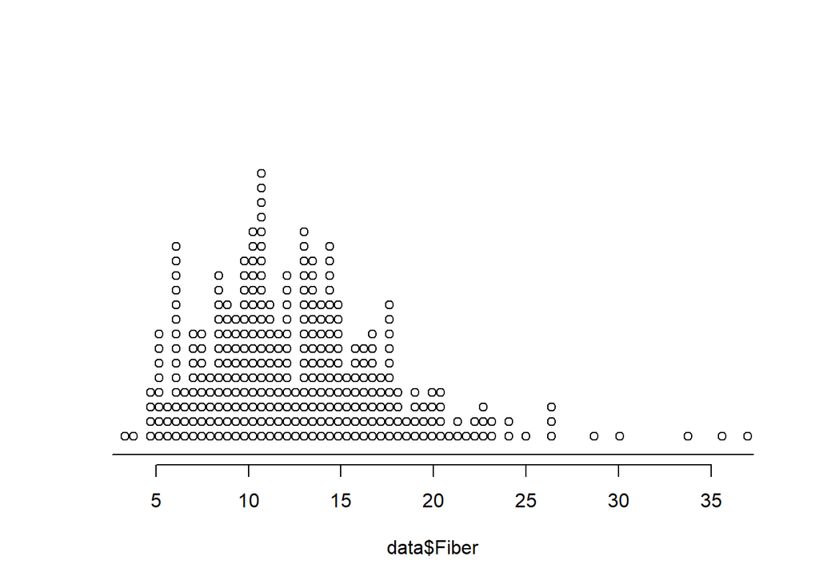

```r
dotPlot(data$Fiber)
```

I am 99% confident that the true average number of grams of fiber per day that people eat is within the range (12.01,13.57). ______________________________________________________________________________________________

Q2a. Construct 95% confidence interval for the effect of gender on smoking.

Hypothesis:

$$H_0:p_1=p_2 \quad vs \quad H_a:p_1 \ne
p_2$$

Confidence Interval:

$$(\hat{p_1}-\hat{p_2})\pm
z^{\star}\cdot \sqrt{ \frac{\hat{p_1}(1-\hat{p_1})}{n_1}+
\frac{\hat{p_2}(1-\hat{p_2})}{n_2}}$$

```r
data<-read.csv("NutritionStudy.csv")

males <- filter(data, Sex == "Male")
p1.hat <- mean(males$Smoke == "Yes")
n1 = nrow(males)

females <- filter(data, Sex == "Female")
p2.hat <- mean(females$Smoke == "Yes")
n2 = nrow(females)

statistic<-p1.hat-p2.hat
z.score<-1.96
SE = sqrt(p1.hat*(1-p1.hat)/n1 + p2.hat*(1-p2.hat)/n2)
CI.lower<-statistic - z.score*(SE)
CI.upper<-statistic + z.score*(SE)
```

```r
CI.lower
```

```
## [1] -0.08484522
```

```r
CI.upper
```

```
## [1] 0.1544423
```

Confidence Interval:

$$(-0.08484522,0.1544423)$$

I am 95% confident that the true population proportion of the effect of gender on smoking is within the confidence interval. ______________________________________________________________________________________________

Q2b. Do the sample data provide evidence that the effect of gender on smoking is statistically significant? In other words, Is there evidence of a difference in the percentage of current smokers by gender?

Null Hypothesis:

$$H_0:\mu_1=\mu_2$$

95% Confidence Interval:

$$(-0.08, 0.15)$$

The 95% confidence interval for the proportion difference contains the null hypothesis value of 0. ______________________________________________________________________________________________

Q3. Does smoking decrease beta-carotene levels in the blood (betaPlasma)? Justify your answer with confidence interval and a p-value.

Hypothesis:

$$H_0:\mu_1=\mu_2 \quad vs \quad H_a:\mu_1
< \mu_2$$
Confidence Interval:

$$(\bar{x_1}-\bar{x_2})\pm
t^{\star}\cdot \sqrt{\frac{s^2_1}{n_1}+\frac{s^2_2}{n_2}}$$
Test Statistic:

$$\frac{(\overline{x_1} - \overline{x_2})
- 0}{\sqrt{\frac{s^2_1}{n1} + \frac{s^2_1}{n1}}}$$

```r
data<-read.csv("NutritionStudy.csv")

smoke.yes<-filter(data, Smoke=="Yes")
smoke.no<-filter(data, Smoke=="No")

#Test Statistic
xbar1 = mean(smoke.yes$BetaPlasma)
xbar2 = mean(smoke.no$BetaPlasma)

s1 = sd(smoke.yes$BetaPlasma)
s2 = sd(smoke.no$BetaPlasma)

n1 = nrow(smoke.yes)
n2 = nrow(smoke.no)

testStat<-(xbar1 - xbar2 - 0) / sqrt(s1^2/n1 + s2^2/n2)

#Confidence Interval
df<-min(n1-1,n2-1)
CI.lower<-(xbar1-xbar2) - qt(0.95,df,lower.tail=T)* (sqrt(s1^2/n1 + s2^2/n2))

CI.upper<-(xbar1-xbar2) + qt(0.95,df,lower.tail=T)* (sqrt(s1^2/n1 + s2^2/n2))


#P-value
p.value<-pnorm(-4.742105, lower.tail=T)
```

```r
testStat
```

```
## [1] -4.742105
```

```r
CI.lower
```

```
## [1] -107.5701
```

```r
CI.upper
```

```
## [1] -51.24192
```

```r
p.value
```

```
## [1] 1.057545e-06
```

Test Statistic:

$$-4.742105$$
Confidence Interval:

$$(-107.5701, -51.24192)$$
p.value:

$$1.057545e-06$$

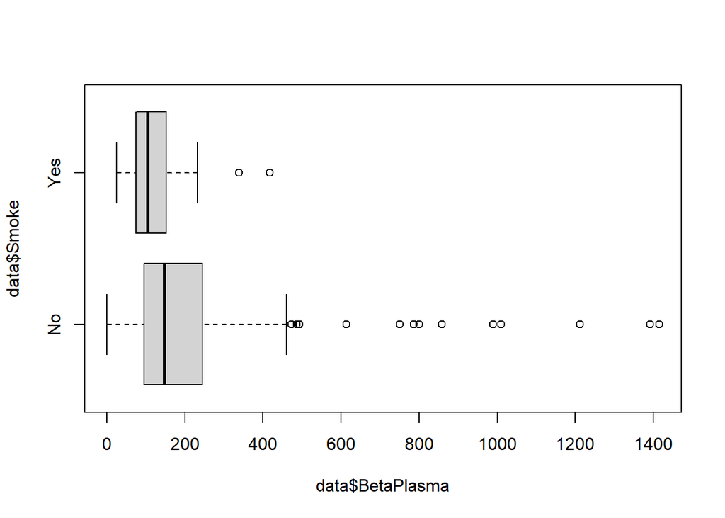

```r
boxplot(data$BetaPlasma~data$Smoke, horizontal = T)
```

With a p-value being less than 0.05, there is strong evidence that smoking decreases the beta-carotene levels in the blood. Along with the test statistic NOT being contained within the Confidence Interval. ______________________________________________________________________________________________

Q4a. Construct 90% confidence interval for the effect of sex on beta-carotene levels in the blood.

Hypothesis:

$$H_0:\mu_1=\mu_2 \quad vs \quad H_a:\mu_1
\ne \mu_2$$
Confidence Interval:

$$(\bar{x_1}-\bar{x_2})\pm
t^{\star}\cdot \sqrt{\frac{s^2_1}{n_1}+\frac{s^2_2}{n_2}}$$

```r
data<-read.csv("NutritionStudy.csv")

# Confidence Interval
females<-filter(data,Sex=="Female")
xbar1<-mean(females$BetaPlasma)

males<-filter(data,Sex=="Male")
xbar2<-mean(males$BetaPlasma)

stat<-xbar1 - xbar2

n1<-(nrow(females)-1)
n2<-(nrow(males)-1)
df<-min(n1,n2)

s1<-sd(females$BetaPlasma)
s2<-sd(males$BetaPlasma)

t.score<-qt(0.95,df)
SE = sqrt(s1^2/n1 + s2^2/n2)

CI.lower<- stat - t.score*(SE)
CI.upper<- stat + t.score*(SE)
```

```r
CI.lower
```

```
## [1] 7.514217
```

```r
CI.upper
```

```
## [1] 87.62131
```

Confidence Interval:

$$(7.514217,87.62131)$$

I am 90% sure that the true population mean is within the confidence interval. ______________________________________________________________________________________________ Q4b.Does sex have any significant effect on beta-carotene levels in the blood?

Test Statistic:

$$\frac{(\overline{x_1} - \overline{x_2})
- 0}{\sqrt{\frac{s^2_1}{n1} + \frac{s^2_1}{n1}}}$$

```r
testStat<-(xbar1 - xbar2 - 0) / sqrt(s1^2/n1 + s2^2/n2)
p.value<-pnorm(testStat)
```

```r
testStat
```

```
## [1] 1.998593
```

```r
p.value
```

```
## [1] 0.9771738
```

Test Statistic:

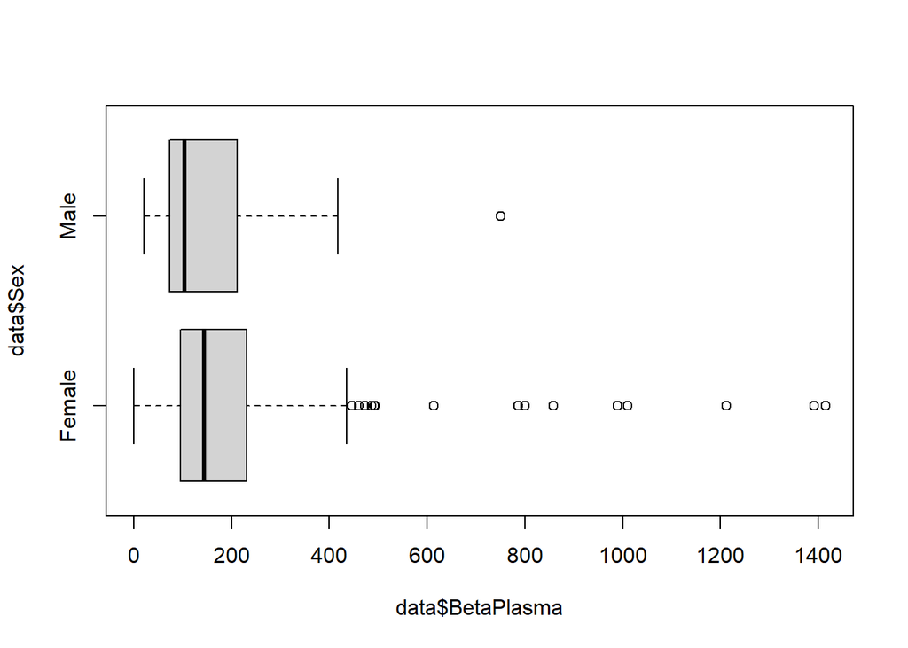

```r
boxplot(data$BetaPlasma~data$Sex, horizontal = T)
```

5. Are the amount of alcohol consumption and the age of the people significantly related?

Hypothesis:

$$H_0:\rho=0 \quad vs \quad H_a:\rho \ne
0$$
Confidence Interval:

$$(\bar{x_1}-\bar{x_2})\pm
t^{\star}\cdot \sqrt{\frac{s^2_1}{n_1}+\frac{s^2_2}{n_2}}$$

```r
data<-read.csv("NutritionStudy.csv")


cor(data$Alcohol,data$Age)
```

```
## [1] 0.05158327
```

Correlation:

$$0.05158327$$

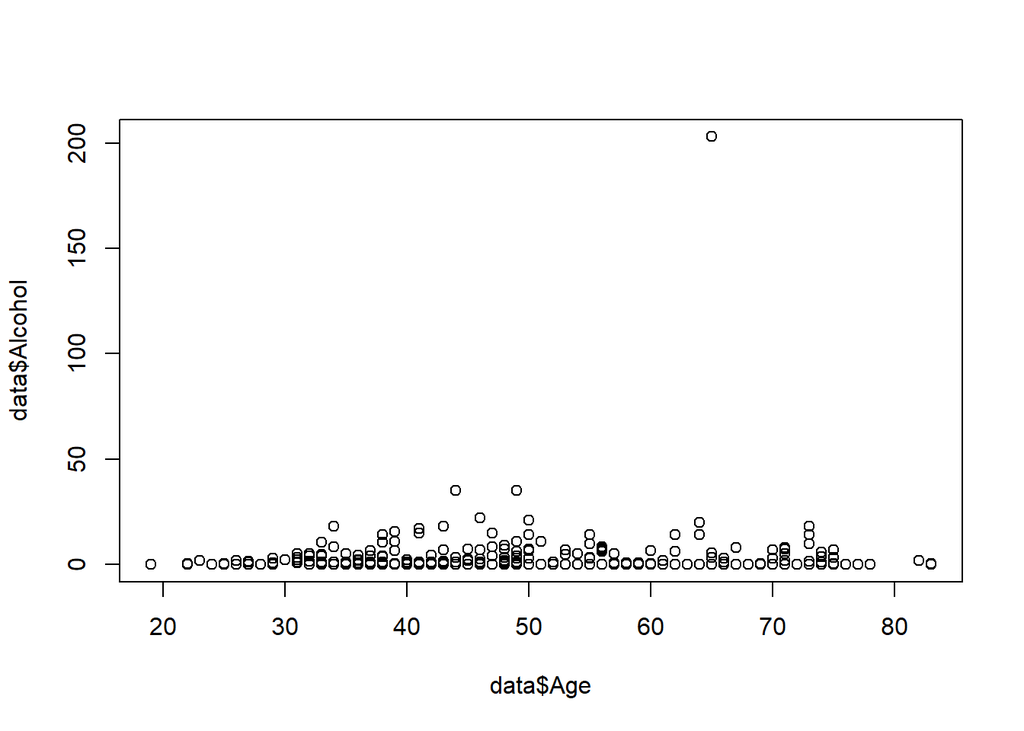

```r
plot(data$Alcohol~data$Age)
```

There is a very slight positive correlation between alcohol consumption and age

6. Which variables listed in the dataset are significantly related to plasma beta carotene?

```r
data<-read.csv("NutritionStudy.csv")
numeric_data <- data[sapply(data, is.numeric)]

correlations <- cor(numeric_data$BetaPlasma, numeric_data)

significant<-(correlations > 0.5) | (correlations < -0.5)
significant
```

```
##         ID   Age Quetelet Vitamin Calories   Fat Fiber Alcohol Cholesterol
## [1,] FALSE FALSE    FALSE   FALSE    FALSE FALSE FALSE   FALSE       FALSE
##      BetaDiet RetinolDiet BetaPlasma RetinolPlasma PriorSmoke
## [1,]    FALSE       FALSE       TRUE         FALSE      FALSE
```

At a (-0.5,0.5) level of significance none of the variables are significantlty related to plasma beta ______________________________________________________________________________________________

7. Is there sufficient evidence that the proportions of smoking status (prior-smoke)- Never, former and current are equal?

Hypothesis:

$$H_0:p_1 - p_2 - p_3 = 0 \quad vs \quad
H_a:p_1 - p_2 - p_3 \ne 0$$
- p value = 1.78434e-14, reject null hypothesis

```r
data<-read.csv("NutritionStudy.csv")
never<-filter(data, PriorSmoke=="1")
former<-filter(data, PriorSmoke=="2")
current<-filter(data, PriorSmoke=="3")

O<-c(nrow(never),nrow(former),nrow(current))
E<-nrow(data)*c(1/3,1/3,1/3)
chsq<-sum((O-E)^2/E)

chi_square_contributions <- (O - E)^2 / E
chi_square_table <- data.frame(
  Category = c("Never", "Former", "Current"),
  Observed = O,
  Expected = E,
  Contribution_to_Chi_Square = chi_square_contributions
)
pchisq(chsq,2,lower.tail = FALSE)
```

```
## [1] 1.78434e-14
```

P-Value:

$$1.78434e-14$$

```r
chi_square_table
```

```
##   Category Observed Expected Contribution_to_Chi_Square
## 1    Never      157      105                  25.752381
## 2   Former      115      105                   0.952381
## 3  Current       43      105                  36.609524
```

Q8. Consider the following variables: fat grams consumed in a day, cholesterol consumed in mg per day, and age in years. Which of the above factors significantly affects the variable calories consumed in a day at a 5% level of significance?

```r
data <- read.csv("NutritionStudy.csv")

model <- lm(Calories ~ Fat + Cholesterol + Age, data=data)

summary(model)
```

```
##
## Call:
## lm(formula = Calories ~ Fat + Cholesterol + Age, data = data)
##
## Residuals:
##    Min     1Q Median     3Q    Max
## -690.7 -176.6  -47.0  155.8 3315.6
##
## Coefficients:
##             Estimate Std. Error t value Pr(>|t|)
## (Intercept) 512.9462    86.5106   5.929 8.09e-09 ***
## Fat          16.2645     0.7925  20.523  < 2e-16 ***
## Cholesterol   0.4208     0.2015   2.089   0.0375 *
## Age          -1.4205     1.3040  -1.089   0.2769
## ---
## Signif. codes:  0 '***' 0.001 '**' 0.01 '*' 0.05 '.' 0.1 ' ' 1
##
## Residual standard error: 331.9 on 311 degrees of freedom
## Multiple R-squared:  0.7643, Adjusted R-squared:  0.762
## F-statistic: 336.1 on 3 and 311 DF,  p-value: < 2.2e-16
```

Fat and Cholesterol are both significant at a 5% level as both their p-values are less than 0.05. ______________________________________________________________________________________________

Q9a Estimate the effect of smoking on cholesterol levels and provide a 95% confidence interval for it.

Confidence Interval:

## $$(\bar{x_1}-\bar{x_2})\pm t^{\star}\cdot \sqrt{\frac{s^2_1}{n_1}+\frac{s^2_2}{n_2}}$$

```r
data<-read.csv("NutritionStudy.csv")

smoking.yes<-filter(data,Smoke=="Yes")
smoking.no<-filter(data,Smoke=="No")

xbar1<-mean(smoking.yes$Cholesterol)
xbar2<-mean(smoking.no$Cholesterol)

s1<-sd(smoking.yes$Cholesterol)
s2<-sd(smoking.no$Cholesterol)

n1<-nrow(smoking.yes)
n2<-nrow(smoking.no)

stat<-(xbar1-xbar2)
df<-min(n1-1,n2-1)

t.score<-qt(0.05,df,lower.tail=F)

CI.lower<-stat - t.score * (sqrt(s1^2/n1 + s2^2/n2))
CI.upper<-stat + t.score * (sqrt(s1^2/n1 + s2^2/n2))
```

```r
CI.lower
```

```
## [1] -4.856816
```

```r
CI.upper
```

```
## [1] 74.5087
```

Q9b. Is the effect of smoking on cholesterol levels significant? Make your decision based on confidence interval and p-value.

```r
# pvalue
pnorm(stat/sqrt(s1^2/n1 + s2^2/n2), lower.tail=F)*2
```

```
## [1] 0.139918
```

P-Value:

$$0.139918$$

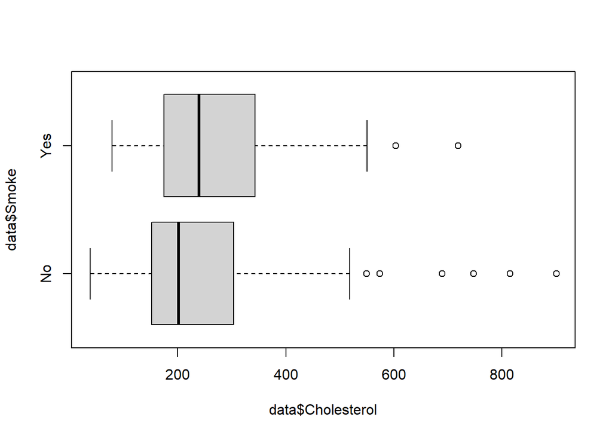

```r
boxplot(data$Cholesterol~data$Smoke, horizontal = T)
```

The p-value is greater than 0.05 therefore the effect of smoking on cholesterol levels is not significant. ______________________________________________________________________________________________

10. Do the sample data provide evidence that vitamin use affects retinol (micro nutrient in the blood) levels? Justify your answer with a p-value.

```r
data<-read.csv("NutritionStudy.csv")
model1<-lm(RetinolPlasma~VitaminUse, data=data)
summary(model1)
```

```
##
## Call:
## lm(formula = RetinolPlasma ~ VitaminUse, data = data)
##
## Residuals:
##     Min      1Q  Median      3Q     Max
## -434.16 -139.47  -33.47  114.18 1131.53
##
## Coefficients:
##                      Estimate Std. Error t value Pr(>|t|)
## (Intercept)            595.47      19.88  29.960   <2e-16 ***
## VitaminUseOccasional     1.80      30.49   0.059    0.953
## VitaminUseRegular       17.70      27.47   0.644    0.520
## ---
## Signif. codes:  0 '***' 0.001 '**' 0.01 '*' 0.05 '.' 0.1 ' ' 1
##
## Residual standard error: 209.4 on 312 degrees of freedom
## Multiple R-squared:  0.001575,   Adjusted R-squared:  -0.004825
## F-statistic: 0.2461 on 2 and 312 DF,  p-value: 0.782
```

```r
anova(model1)
```

```
## Analysis of Variance Table
##
## Response: RetinolPlasma
##             Df   Sum Sq Mean Sq F value Pr(>F)
## VitaminUse   2    21580   10790  0.2461  0.782
## Residuals  312 13680538   43848
```

P-Value (Occasional):

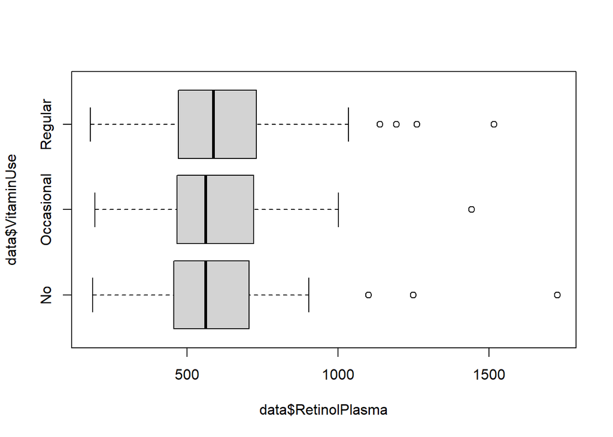

```r
boxplot(data$RetinolPlasma~data$VitaminUse, horizontal = T)
```

Both p-values were far greater than 0.05 therefore no there is no evidence that vitamn use effects retinol levels ______________________________________________________________________________________________

11. Who (Man or Woman) is more likely to take a vitamin? Is there a significant association between vitaminuse and the sex of the participants?

```r
data<-read.csv("NutritionStudy.csv")


chisq.test(data$Sex, data$VitaminUse, correct=FALSE)
```

```
##
##  Pearson's Chi-squared test
##
## data:  data$Sex and data$VitaminUse
## X-squared = 11.071, df = 2, p-value = 0.003944
```

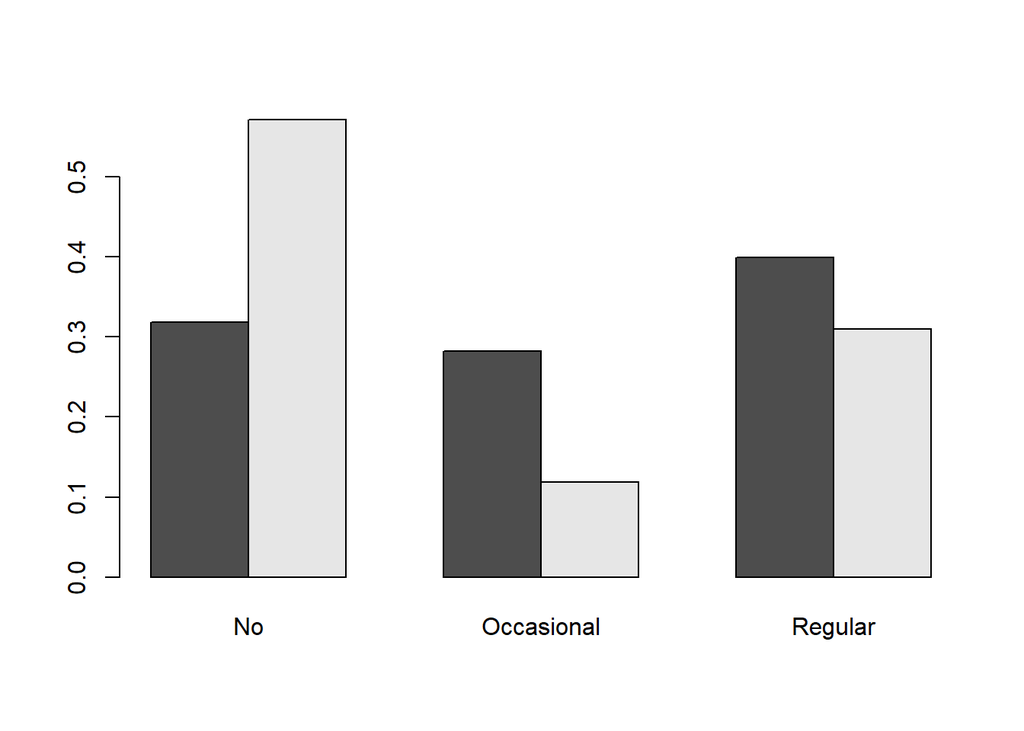

```r
Tab<-table(data$Sex, data$VitaminUse)
prop<-prop.table(Tab, 1)
barplot(prop, beside=TRUE)
```

```r
chisq.test(Tab, correct=TRUE)
```

```
##
##  Pearson's Chi-squared test
##
## data:  Tab
## X-squared = 11.071, df = 2, p-value = 0.003944
```